# Navigation Bar

[figure not shown]

[figure not shown]

[figure not shown]

Using flexdashboard - https://rmarkdown.rstudio.com/flexdashboard/using.html

# Menu A

個々のページで記載したコメントは個々のページでしか表示されません。

You can link to a dashboard page with either of the following syntaxes:

Page 2

Page Two

Link to hidden Page 5

The second syntax is used when you want a custom name for the link (rather than just using the page title).

|  | Sepal.Length | Sepal.Width | Petal.Length | Petal.Width | Species |
| --- | --- | --- | --- | --- | --- |
| 1 | 5.1 | 3.5 | 1.4 | 0.2 | setosa |
| 2 | 4.9 | 3 | 1.4 | 0.2 | setosa |
| 3 | 4.7 | 3.2 | 1.3 | 0.2 | setosa |
| … | … | … | … | … | NA |
| 148 | 6.5 | 3 | 5.2 | 2 | virginica |
| 149 | 6.2 | 3.4 | 5.4 | 2.3 | virginica |
| 150 | 5.9 | 3 | 5.1 | 1.8 | virginica |

# Page 1

Page 1

### Chart A, Title as header

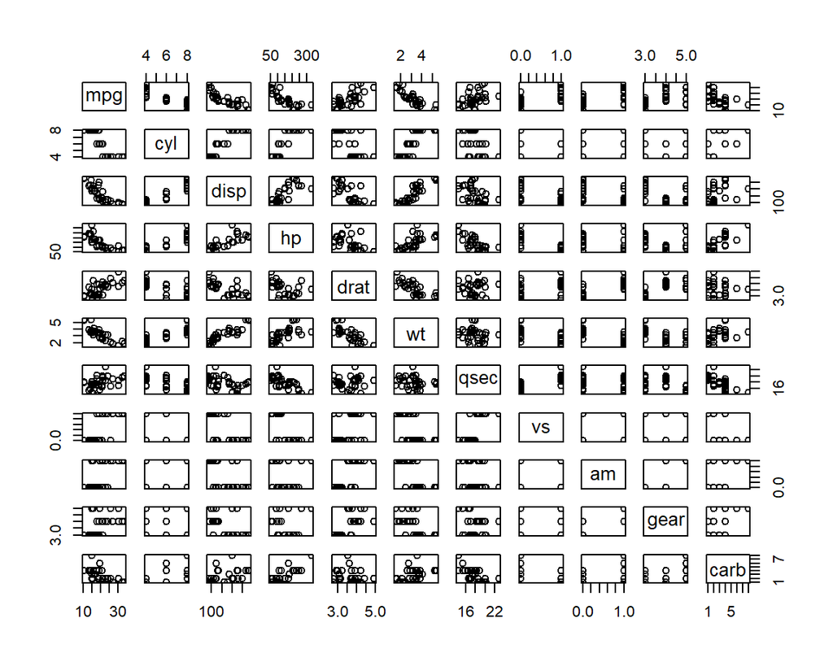

> Note, as footer

### Chart A-2

{.no-title}を指定するとタイトルを消すことができる。ただし、これはレベル３（`###`）見出しのみに適用可能。

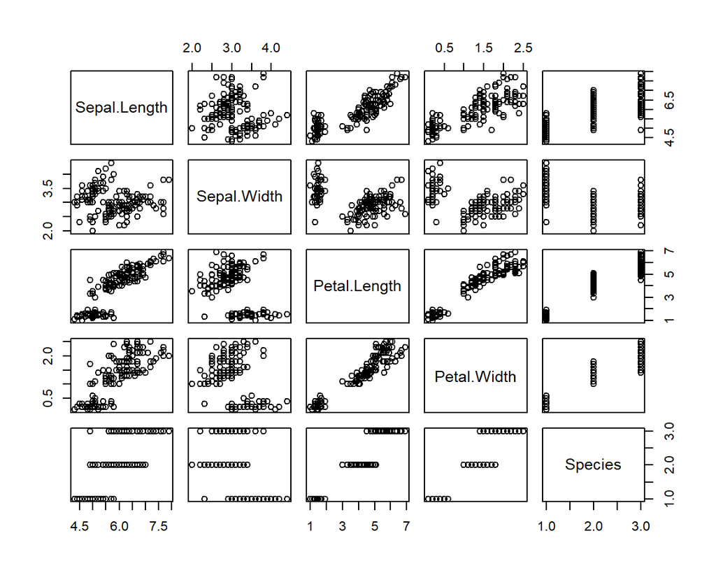

> Note as footer

# Page 2

Page 2

# Page 3

Page 3

# Page 4

Page 4

# Page 5

Page 5

# Nav-bar

[Navigation Bar](https://rmarkdown.rstudio.com/flexdashboard/using.html#navigation_bar)

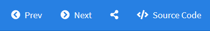

メニューの右側にこのようなメニューを表示させる場合、YAMLの`output`に以下のように指定をします。リンクは固定リンクとなる点に留意してください。

```
---
output:
  flexdashboard::flex_dashboard:
    navbar:
      - { title: "Prev", icon: "fa-chevron-circle-left", href: ""}
      - { title: "Next", icon: "fa-chevron-circle-right ", href: ""}
    social: [ "menu" ]
    source_code: embed
---
```

| 設定 | 概要 |
| --- | --- |
| navbar | HTMLのリンクを設定します。アイコン表示は常に文字の左側になります。 |
| social | SNSシェアリンクを作成するためのリンク集が表示されます。 |
| source_code | flexdashboards自体のコードが表示されるようになります。 |

このようなリンクを利用するとプロジェクトごとにflexdashboardページを作成し、順次表示させるような使い方ができます。

# Storyboards

[Storyboards](https://rmarkdown.rstudio.com/flexdashboard/using.html#storyboards) style.

### Storyboadsは表示を最大三分割して表示することができる表示形式です。最上段は画面切り替えリンクを兼ねた要約表示部分です。

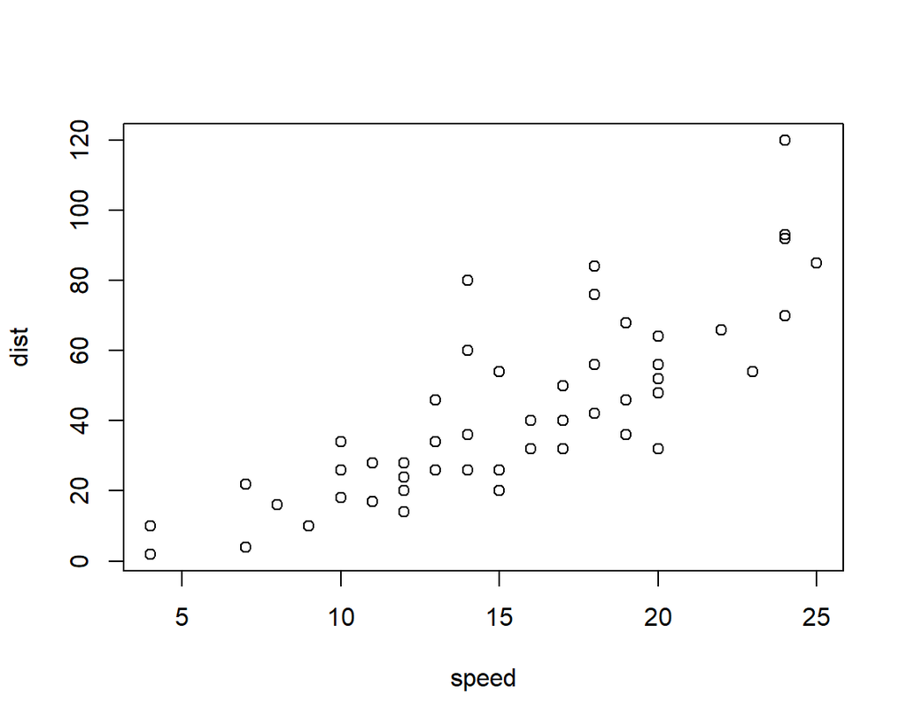

> この画面がメインとなるフレームです。

[Commentary](https://rmarkdown.rstudio.com/flexdashboard/using.html#commentary) フレームはメイン・フレームの左横に展開されるフレームで補足説明などを記載することが可能です。Commentaryフレームは`***`で区切って記述します。

```
### Frame 1

***

Some commentary about Frame 1.
```

なお、Commentaryフレームではフッター（ノート）を記述することはできません。

### 紙芝居のようにストーリー立ててデータを見せることができます。ヘッダーの代わりにこのような切り替えフレームが表示されます。

### 切り替えフレームの数に制限はなく、画面からあふれた場合は自動的に左右にスクロールしてくれます。

### Storyboardsはページ単位（`#`レベル）で設定することができます。ページ単位で指定する場合は{.storyboard}をタイトルの後ろに記述してください。

```
---
title: "Storyboard"
output:
  flexdashboard::flex_dashboard:
    storyboard: true
---

Analysis {.storyboard}
=========================================

### Frame 1


### Frame 2


Details
=========================================
```

````r
---
title: "Navigation Bar"
output:
  flexdashboard::flex_dashboard:
    navbar:
      # - { title: "Prev Project", href: "", align: left}
      # - { title: "Next Project", href: "", align: left}
      - { title: "Prev", icon: "fa-chevron-circle-left", href: ""}
      - { title: "Next", icon: "fa-chevron-circle-right ", href: ""}
    self_contained: true
    # social: [ "twitter", "facebook" ]
    social: [ "menu" ]
    source_code: embed
    storyboard: true
    vertical_layout: fill
---

Using flexdashboard - https://rmarkdown.rstudio.com/flexdashboard/using.html

```{r setup, include=FALSE}
require(psych)
require(tidyverse)

head_tail <- function (df, n = 3) {
  psych::headTail(df, top = n, bottom = n) %>% knitr::kable()
}
```


Menu A {data-icon="fa-list"}
=====================================
個々のページで記載したコメントは個々のページでしか表示されません。

You can link to a dashboard page with either of the following syntaxes:

[Page 2]

[Page Two](#page-2)

Link to hidden [Page 5](#page-5)

The second syntax is used when you want a custom name for the link
(rather than just using the page title).

```{r}
iris %>% head_tail()
```



Page 1 {data-navmenu="Menu A" data-icon="fa-list" data-orientation=cols}
=====================================
Page 1

### Chart A, Title as header

```{r}
plot(mtcars)
```

> Note, as footer


### Chart A-2 {.no-title}
{.no-title}を指定するとタイトルを消すことができる。ただし、これはレベル３（`###`）見出しのみに適用可能。

```{r}
plot(iris)
```

> Note as footer

Page 2 {data-navmenu="Menu A" data-icon="fa-list" data-orientation=rows}
=====================================
Page 2

### Chart B

```{r}
```

### Chart C

```{r}
```


Page 3 {data-navmenu="Menu B"}
=====================================
Page 3


Page 4 {data-navmenu="Menu B"}
=====================================
Page 4


Page 5 {.hidden}
=====================================
Page 5


Nav-bar {data-icon="fa-bars"}
==============================================================================
[Navigation Bar ](https://rmarkdown.rstudio.com/flexdashboard/using.html#navigation_bar){target="_blank" title="flexdashboard for R"}

![](./navbar.png)
メニューの右側にこのようなメニューを表示させる場合、YAMLの`output`に以下のように指定をします。リンクは固定リンクとなる点に留意してください。


```
---
output:
  flexdashboard::flex_dashboard:
    navbar:
      - { title: "Prev", icon: "fa-chevron-circle-left", href: ""}
      - { title: "Next", icon: "fa-chevron-circle-right ", href: ""}
    social: [ "menu" ]
    source_code: embed
---
```

設定   | 概要
-------|-----------------------------
navbar | HTMLのリンクを設定します。アイコン表示は常に文字の左側になります。
social | SNSシェアリンクを作成するためのリンク集が表示されます。
source_code | flexdashboards自体のコードが表示されるようになります。




このようなリンクを利用するとプロジェクトごとにflexdashboardページを作成し、順次表示させるような使い方ができます。


Storyboards {data-icon="fa-bars" .storyboard}
==============================================================================
[Storyboards ](https://rmarkdown.rstudio.com/flexdashboard/using.html#storyboards){target="_blank" title="flexdashboard for R"} style.


### Storyboadsは表示を最大三分割して表示することができる表示形式です。最上段は画面切り替えリンクを兼ねた要約表示部分です。

```{r}
plot(cars)
```

> この画面がメインとなるフレームです。

***

[Commentary ](https://rmarkdown.rstudio.com/flexdashboard/using.html#commentary){target="_blank" title="flexdashboard for R"} フレームはメイン・フレームの左横に展開されるフレームで補足説明などを記載することが可能です。Commentaryフレームは`***`で区切って記述します。


```
### Frame 1

***

Some commentary about Frame 1.
```


なお、Commentaryフレームではフッター（ノート）を記述することはできません。


### 紙芝居のようにストーリー立ててデータを見せることができます。ヘッダーの代わりにこのような切り替えフレームが表示されます。


### 切り替えフレームの数に制限はなく、画面からあふれた場合は自動的に左右にスクロールしてくれます。

### Storyboardsはページ単位（`#`レベル）で設定することができます。ページ単位で指定する場合は{.storyboard}をタイトルの後ろに記述してください。

```
---
title: "Storyboard"
output:
  flexdashboard::flex_dashboard:
    storyboard: true
---

Analysis {.storyboard}
=========================================

### Frame 1


### Frame 2


Details
=========================================
```
````